# Sti_pred_2020

A while back I [collected some data about PhD stipends](https://dambrosicode.github.io/DambrosiCode.github.io/data%20science/stipend_I/), and made an [interactive map with the Living Wage Ratio data](https://dambrosicode.github.io/DambrosiCode.github.io/data%20science/stipend_II/). I've since graduated with my masters and don't plan on going for a PhD, but I did want to play around with the data a little bit more. So I decided to play around with some machine learning algorithms and make some models to see if we could predict stipend amount with predictor variables. For this we'll use supervised learning: neural networks, multilinear regression, and random forests.

We'll start with our old dataset you can look at [here](https://github.com/DambrosiCode/Stipend-Data). Last time we looked at living wage ratio, but now I'm more interested in the actual stipend amount (IE: how many thousands of dollars a year). To predict this we'll use independent variables that we have the most of and would most obviously correlate to stipend amount. I won't do any feature selection here, since there aren't too many variables, but maybe we'll take a look in the future.

```python
import pandas as pd
import matplotlib.pyplot as plt
import numpy as np

#We'll be coorelating Stipend with State, Subject, and University
categories = ['Stipend', 'State', 'University', 'Subject']
stip = pd.read_csv('/Python Projects/Stipend Analysis/stipend_and_locations.csv',
                   encoding = 'latin-1')[categories]


stip = stip.replace(r'^\s*$', np.nan, regex=True)

stip[stip['State']=='Alaska']
stip = stip.dropna() #remove NAs
print(len(stip)) #take a look at size of data
```

```
3348
```

Now it's time for some preprocessing. To make sure everything is homogeneous we'll all the strings to lower case.

```python
#subject containing dictionary
sub_dict = {}

#lsit of all subjects
subs = stip['Subject'].str.lower()
#list of unique subjects
uniq_subs = subs.unique()
```

Next we have a problem: because the website we scraped this data from took user input, subject names aren't standardized. For instance someone getting their PhD in biology could have said "biology" or "biological science". As humans we know these are the same subject, but to a literal computer these are separate subjects, and since we want to train the computer with supervised learning we should make the groups as homogeneous as possible.

Now we could go through each entry, and give it our own category. But there's over 3,000 rows of data and who has that kind of time? Instead we're going to use Levenshtein distance by way of the fuzzywuzzy package. The Levenshtein distance compares two strings and gives a nice numerical output on "like" they are. For instance "Python" and "Python" have a distance of 0, while "Monty" and "Python" have a distance of 6. You can read more about it [here](https://www.google.com/search?q=levenshtein+distance+explained&oq=levenshtein+distance+expl&aqs=chrome.0.0j69i57j0l3.4924j1j4&sourceid=chrome&ie=UTF-8).

The fuzzywuzzy package is based on the the Levenshtein distance, and allows us to get the closest matches of our target string and a list of strings. What we're going to do is collect all of the unique subjects and find their nearest subject based on our chosen parameters. So while "biology", "bio", and "biological sciences" are all objectively different strings, our function will tell the computer that they're close enough to be considered the same, and rename them all to the shortest string, in this case "bio".

```python
#location of all subjects
for idx,unique_subject in enumerate(uniq_subs):
    sub_dict[unique_subject] = subs[uniq_subs[idx] == subs].index

from fuzzywuzzy import process

#find dictionary keys that are similar and merge them
sub_dict = {}

sort = pd.Series(sorted(subs, key=len))
#find matches
for i, subject in enumerate(sort):
    try:
        #sort out smaller matches first
        if i < 198:
            cutoff = 100
        else:
            cutoff = 90

            #top 5 matches
        matches = process.extractBests(sort[i], sort, score_cutoff=cutoff, limit = len(sort))
        #index of matches
        indxs = [item[2] for item in matches]
        #match subject and its matched subjects in a dictionary
        sub_dict[subject] = [item[0] for item in matches]
        #remove matches from list
        sort = sort.drop(indxs)
    except:
        pass


simp_subs = []
for subject in subs:
    simp_subs.append([sub for sub, matches in sub_dict.items()
               if subject in matches][0])

'''
with open('sub_dict.csv', 'w') as f:
    for key in sub_dict.keys():
        f.write("%s,%s\n"%(key,sub_dict[key]))
f.close()
'''

#cursory look
pd.DataFrame([simp_subs, subs]).T

simp_stip = stip
simp_stip['Subject'] = simp_subs
simp_stip = simp_stip.reset_index().iloc[:,1:]
```

Taking a quick look at what we've done we can see that it's worked. "Chemical engineering" and "biomedical engineering" are now just "engineering", etc.

```python
pd.DataFrame([simp_subs, subs]).T.iloc[:11]
```

|  | 0 | 1 |
| --- | --- | --- |
| 0 | engineering | chemical engineering |
| 1 | engineering | chemical engineering |
| 2 | engineering | biomedical engineering |
| 3 | fpe | fpe |
| 4 | fpe | fpe |
| 5 | ece | ece |
| 6 | ece | ece |
| 7 | chemistry | chemistry and biochemistry |
| 8 | informatics | biomedical informatics |
| 9 | biology | biology |
| 10 | law | law |

Because most ML algorithms need numerical data, string inputs won't do. Now we could convert the strings to unique identifiers (IE: "bio"=0, "engineering"=1, "chemistry"=2 etc), but our categories are unique and it doesn't make sense to apply math to them. For instance, if "bio"=0 and "chemistry"=2 half-way between them would be engineering (1). This of course makes no sense, so we have to use one-hot encoding.

The way one-hot works is by creating a matrix of 1s and 0s, and columns of our variables. For example if we had the categories "bio", "chemistry", and "engineering" a one-hot encoded table would look like this

| bio | chemistry | engineering |
| --- | --- | --- |
| 1 | 0 | 0 |
| 0 | 1 | 0 |
| 0 | 0 | 1 |

Where the 1s denote the value existing, and 0s the opposite.

Lastly we'll split the data into training and testing (80/20) sets to prevent over-fitting.

```python
#remmove outliers
f = simp_stip[simp_stip['Stipend'].between(simp_stip['Stipend'].quantile(.08),
                                           simp_stip['Stipend'].quantile(.94))]

#remove sci-notation
pd.options.display.float_format = '{:.2f}'.format

#onehot encode categorical data
from sklearn.model_selection import train_test_split
X = f.iloc[:,2:]
#X = simp_stip['Subject'].values.reshape(-1,1) #State, Uni, Sub
y = f['Stipend'].values.reshape(-1,1) #LW ratio
#y = simp_stip['Stipend'].values.reshape(-1,1) #LW ratio

#using SKlearn package
from sklearn.preprocessing import OneHotEncoder
from sklearn.preprocessing import OrdinalEncoder
from sklearn.linear_model import LinearRegression


#encoder = OrdinalEncoder()
encoder = OneHotEncoder(sparse = True, categories='auto')
X_encoded = encoder.fit_transform(X)

#plit data into training and testing
X_train, X_test, y_train, y_test = train_test_split(X_encoded, y, test_size=0.2,
                                                    random_state=42)
```

Finally we can start modeling.

```python
model = LinearRegression()
model.fit(X=X_train, y=y_train)

#Test model
y_pred = model.predict(X_test)
```

We'll judge our model on a few metrics. First we're going to simply take a look at the actual and predicted stipends for the first 5 columns as a sanity check. We can see that surface level the predicted is actually pretty close to the predicted. A few thousand off, but nothing serious.

```python
df = pd.DataFrame({'Actual':y_test.flatten(), 'Predicted':y_pred.flatten(),
                   'Diff':y_test.flatten()-y_pred.flatten()})

print(df.head())
```

```
    Actual  Predicted     Diff
0 25000.00   27458.31 -2458.31
1 36900.00   32072.69  4827.31
2 23659.00   22466.77  1192.23
3 22500.00   25091.83 -2591.83
4 29000.00   24603.90  4396.10
```

Next up is the actual metrics. Importantly we want to look at R^2 (how close our data is to the slope where 0 unrelated and 1 is perfect relation), Mean Absolute Error (actual error for the overall predictions), and Slope (how perfectly does predicted correlate to actual), and intercept (if the actual stipend is at 0 then what is the predicted). I am also going to graph the Predicted v/ Actual stipends.

For the most part this seems to be a decent model. The intercept tells us that the predicted values are a little biased to be higher than the actual, but it's not overly misleading.

```
Summary
R^2 Score: 0.5529276479667038
Mean Absolute Error: 3037.842478302593
Mean Squared Error: 15947894.766088717
Root Mean Squared Error: 3993.4815344619683
```

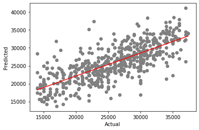

```
Slope: [[0.64162057]]
Intercept: [9294.28189054]
```

```python
from sklearn import metrics
print('\nSummary')
print('R^2 Score:', metrics.r2_score(y_test, y_pred))
print('Mean Absolute Error:', metrics.mean_absolute_error(y_test, y_pred))
print('Mean Squared Error:', metrics.mean_squared_error(y_test, y_pred))
print('Root Mean Squared Error:', np.sqrt(metrics.mean_squared_error(y_test, y_pred)))

x = df['Actual']
y = df['Predicted']

plt.scatter(x=x, y=y, color='gray')
plt.plot(np.unique(x), np.poly1d(np.polyfit(x, y, 1))(np.unique(x)), color='red')

plt.xlabel('Actual')
plt.ylabel('Predicted')
plt.show()

model.fit(x.values.reshape(-1,1), y.values.reshape(-1,1))
print('Slope:', model.coef_)
print('Intercept:', model.intercept_)
```

```
Summary
    Actual  Predicted     Diff
0 25000.00   29500.00 -4500.00
1 36900.00   32844.00  4056.00
2 23659.00   17800.00  5859.00
3 22500.00   21580.00   920.00
4 29000.00   28300.00   700.00

Summary
R^2 Score: 0.3262852051041568
Mean Absolute Error: 3632.0693240901214
Mean Squared Error: 24032648.412478335
Root Mean Squared Error: 4902.310517753678
```

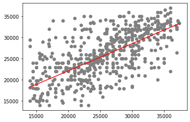

```
Slope: [[0.58472777]]
Intercept: [10964.6638861]
```

```python
from sklearn.neural_network import MLPClassifier
mlp = MLPClassifier(hidden_layer_sizes=(100,1000),max_iter=500,random_state=42)
mlp.fit(X_train, y_train.ravel())

mlp_y_pred = mlp.predict(X_test)

print('\nSummary')
mlp_df = pd.DataFrame({'Actual':y_test.flatten(), 'Predicted':mlp_y_pred.flatten(), 'Diff':y_test.flatten()-mlp_y_pred.flatten()})
print(mlp_df.head())

print('\nSummary')
print('R^2 Score:', metrics.r2_score(y_test, mlp_y_pred))
print('Mean Absolute Error:', metrics.mean_absolute_error(y_test, mlp_y_pred))
print('Mean Squared Error:', metrics.mean_squared_error(y_test, mlp_y_pred))
print('Root Mean Squared Error:', np.sqrt(metrics.mean_squared_error(y_test, mlp_y_pred)))

plt.scatter(y_test, mlp_y_pred, color='gray')
plt.plot(np.unique(x), np.poly1d(np.polyfit(x, y, 1))(np.unique(x)), color='red')
#plt.ylim(1,1.2)
#plt.xlim(0,50000)
plt.show()

model.fit(mlp_df['Actual'].values.reshape(-1,1), mlp_df['Predicted'].values.reshape(-1,1))
print('Slope:', model.coef_)
print('Intercept:', model.intercept_)
```

And lastly we'll use a random-forest model. Ultimately this looks similar to our first multilinear model, the R^2 is a bit lower, and MAE higher (albeit neither by much) but the slope is a bit lower.

```
Summary
    Actual  Predicted     Diff
0 25000.00   29757.90 -4757.90
1 36900.00   30855.09  6044.91
2 23659.00   22716.07   942.93
3 22500.00   25011.36 -2511.36
4 29000.00   24017.46  4982.54

Summary
R^2 Score: 0.5184740285931708
Mean Absolute Error: 3060.9836929995718
Mean Squared Error: 17176918.868297253
Root Mean Squared Error: 4144.504658978833
```

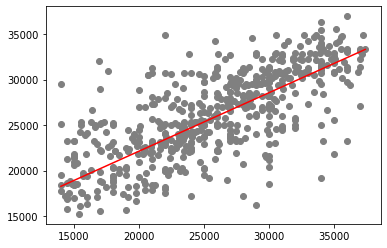

```
Slope: [[0.58468444]]
Intercept: [11081.46787831]
```

```python
f = simp_stip['LW Ratio'].round(0)

#remove sci-notation
pd.options.display.float_format = '{:.2f}'.format

#onehot encode categorical data
from sklearn.ensemble import RandomForestRegressor
rfr = RandomForestRegressor(n_estimators=50, random_state=42)
rfr.fit(X_train, y_train.ravel())
rfr_y_pred = rfr.predict(X_test)

print('\nSummary')
rfr_df = pd.DataFrame({'Actual':y_test.flatten(), 'Predicted':rfr_y_pred.flatten(), 'Diff':y_test.flatten()-rfr_y_pred.flatten()})
print(rfr_df.head())

print('\nSummary')
print('R^2 Score:', metrics.r2_score(y_test, rfr_y_pred))
print('Mean Absolute Error:', metrics.mean_absolute_error(y_test, rfr_y_pred))
print('Mean Squared Error:', metrics.mean_squared_error(y_test, rfr_y_pred))
print('Root Mean Squared Error:', np.sqrt(metrics.mean_squared_error(y_test, rfr_y_pred)))

plt.scatter(y_test, rfr_y_pred, color='gray')
plt.plot(np.unique(x), np.poly1d(np.polyfit(x, y, 1))(np.unique(x)), color='red')
#plt.ylim(1,1.2)
#plt.xlim(0,50000)
plt.show()

model.fit(rfr_df['Actual'].values.reshape(-1,1), rfr_df['Predicted'].values.reshape(-1,1))
print('Slope:', model.coef_)
print('Intercept:', model.intercept_)
```

It looks like all of our model work well, with the multilinear regression model the best, followed by random forest, and finally the neural network.

For more information you can go to these links:

[Multilinear Regression](http://www.stat.yale.edu/Courses/1997-98/101/linmult.htm)

[Neural Networks](https://www.youtube.com/watch?v=aircAruvnKk)

[Random Forest Models](https://towardsdatascience.com/understanding-random-forest-58381e0602d2)

[SKlearn](https://scikit-learn.org/stable/)